# ReneWind

Renewable energy sources play an increasingly important role in the global energy mix, as the effort to reduce the environmental impact of energy production increases.

Out of all the renewable energy alternatives, wind energy is one of the most developed technologies worldwide. The U.S Department of Energy has put together a guide to achieving operational efficiency using predictive maintenance practices.

Predictive maintenance uses sensor information and analysis methods to measure and predict degradation and future component capability. The idea behind predictive maintenance is that failure patterns are predictable and if component failure can be predicted accurately and the component is replaced before it fails, the costs of operation and maintenance will be much lower.

The sensors fitted across different machines involved in the process of energy generation collect data related to various environmental factors (temperature, humidity, wind speed, etc.) and additional features related to various parts of the wind turbine (gearbox, tower, blades, break, etc.).

## Objective

“ReneWind” is a company working on improving the machinery/processes involved in the production of wind energy using machine learning and has collected data of generator failure of wind turbines using sensors. They have shared a ciphered version of the data, as the data collected through sensors is confidential (the type of data collected varies with companies). Data has 40 predictors, 40000 observations in the training set and 10000 in the test set.

The objective is to build various classification models, tune them and find the best one that will help identify failures so that the generator could be repaired before failing/breaking and the overall maintenance cost of the generators can be brought down.

“1” in the target variables should be considered as “failure” and “0” will represent “No failure”.

The nature of predictions made by the classification model will translate as follows:

- True positives (TP) are failures correctly predicted by the model.
- False negatives (FN) are real failures in a wind turbine where there is no detection by model.
- False positives (FP) are detections in a wind turbine where there is no failure.

So, the maintenance cost associated with the model would be:

**Maintenance cost** = `TP*(Repair cost) + FN*(Replacement cost) + FP*(Inspection cost)` where,

- `Replacement cost = $40,000`
- `Repair cost = $15,000`
- `Inspection cost = $5,000`

Here the objective is to reduce the maintenance cost so, we want a metric that could reduce the maintenance cost.

- The minimum possible maintenance cost = `Actual failures*(Repair cost) = (TP + FN)*(Repair cost)`
- The maintenance cost associated with model = `TP*(Repair cost) + FN*(Replacement cost) + FP*(Inspection cost)`

So, we will try to maximize the ratio of minimum possible maintenance cost and the maintenance cost associated with the model.

The value of this ratio will lie between 0 and 1, the ratio will be 1 only when the maintenance cost associated with the model will be equal to the minimum possible maintenance cost.

## Data Description

- The data provided is a transformed version of original data which was collected using sensors.
- Train.csv - To be used for training and tuning of models.
- Test.csv - To be used only for testing the performance of the final best model.
- Both the datasets consist of 40 predictor variables and 1 target variable

## Importing libraries

```python
#Libraries to help with reading data and manipulating data
import numpy as np
import pandas as pd
import matplotlib.pyplot as plt

# Libraries that support data visualization
import matplotlib.pyplot as plt
%matplotlib inline
import seaborn as sns

# Libraries to suppress warnings
import warnings
warnings.filterwarnings("ignore")

sns.set()

# to split the data into train and test
from sklearn.model_selection import train_test_split

# to build logistic regression_model
from sklearn.linear_model import LogisticRegression

# to check model performance
from sklearn.metrics import mean_absolute_error, mean_squared_error, r2_score

# to build linear regression_model using statsmodels
import statsmodels.api as sm

# To be used for data scaling and one hot encoding
from sklearn.preprocessing import StandardScaler, MinMaxScaler, OneHotEncoder

from sklearn.tree import DecisionTreeClassifier
from sklearn import tree

# Removes the limit for the number of displayed columns
pd.set_option("display.max_columns", None)
# Sets the limit for the number of displayed rows
pd.set_option("display.max_rows", 200)

# To build model for prediction
import statsmodels.stats.api as sms
from statsmodels.stats.outliers_influence import variance_inflation_factor
import statsmodels.api as sm
from statsmodels.tools.tools import add_constant
from sklearn.linear_model import LogisticRegression
from sklearn.model_selection import train_test_split, StratifiedKFold, cross_val_score


# To get diferent metric scores
from sklearn.metrics import (
    f1_score,
    accuracy_score,
    recall_score,
    precision_score,
    confusion_matrix,
    roc_auc_score,
    plot_confusion_matrix,
    precision_recall_curve,
    roc_curve,
    make_scorer,
)

from sklearn.model_selection import train_test_split
from sklearn.tree import DecisionTreeClassifier
from sklearn import tree
import sklearn.metrics as metrics

# To tune different models
from sklearn.model_selection import GridSearchCV

# Libraries to suppress warnings
import warnings
warnings.filterwarnings("ignore")


from sklearn.ensemble import AdaBoostClassifier, GradientBoostingClassifier
#To install xgboost library use - !pip install xgboost
from xgboost import XGBClassifier
from sklearn.ensemble import BaggingClassifier, RandomForestClassifier, StackingClassifier
from sklearn.linear_model import LogisticRegression

# To be used for missing value imputation
from sklearn.impute import SimpleImputer

from imblearn.over_sampling import SMOTE
from imblearn.under_sampling import RandomUnderSampler
from sklearn.model_selection import RandomizedSearchCV

# To be used for creating pipelines and personalizing them
from sklearn.pipeline import Pipeline
from sklearn.compose import ColumnTransformer

from imblearn.over_sampling import SMOTE
from imblearn.pipeline import Pipeline
from sklearn.metrics import classification_report
from sklearn.model_selection import train_test_split as tts
```

## Loading Data

```python
# Loading the dataset
train_data = pd.read_csv("Train.csv.csv")
test_data = pd.read_csv("Test.csv")
```

```python
#checking the number of rows and columns in the data
train_data.shape
```

```
(40000, 41)
```

```python
test_data.shape
```

```
(10000, 41)
```

### Observation

1. The train data consists of 40000 rows and 41 columns.
2. The test data consists of 10000 rows and 41 columns.

### Data Overview

```python
train_df = train_data.copy()
```

```python
# let's view the first 5 rows of the data
train_df.head()
```

|  | V1 | V2 | V3 | V4 | V5 | V6 | V7 | V8 | V9 | V10 | V11 | V12 | V13 | V14 | V15 | V16 | V17 | V18 | V19 | V20 | V21 | V22 | V23 | V24 | V25 | V26 | V27 | V28 | V29 | … |
| --- | --- | --- | --- | --- | --- | --- | --- | --- | --- | --- | --- | --- | --- | --- | --- | --- | --- | --- | --- | --- | --- | --- | --- | --- | --- | --- | --- | --- | --- | --- |
| 0 | -4.464606 | -4.679129 | 3.101546 | 0.506130 | -0.221083 | -2.032511 | -2.910870 | 0.050714 | -1.522351 | 3.761892 | -5.714719 | 0.735893 | 0.981251 | 1.417884 | -3.375815 | -3.047303 | 0.306194 | 2.914097 | 2.269979 | 4.394876 | -2.388299 | 0.646388 | -1.190508 | 3.132986 | 0.665277 | -2.510846 | -0.036744 | 0.726218 | -3.982187 | … |
| 1 | -2.909996 | -2.568662 | 4.109032 | 1.316672 | -1.620594 | -3.827212 | -1.616970 | 0.669006 | 0.387045 | 0.853814 | -6.352826 | 4.271718 | 3.162020 | 0.257559 | -3.547127 | -4.284533 | 2.897271 | 1.508313 | 3.667963 | 7.123824 | -4.095749 | 1.015082 | -0.969790 | -0.968207 | 2.063871 | -1.646110 | 0.426956 | 0.734860 | -4.470201 | … |
| 2 | 4.283674 | 5.105381 | 6.092238 | 2.639922 | -1.041357 | 1.308419 | -1.876140 | -9.582412 | 3.469504 | 0.763395 | -2.573231 | -3.349664 | -0.594666 | -5.246841 | -4.309957 | -16.232431 | -0.999690 | 2.318208 | 5.941888 | -3.857972 | -11.599497 | 4.021252 | -6.281194 | 4.633167 | 0.930157 | 6.280225 | 0.850654 | 0.268846 | -2.206445 | … |
| 3 | 3.365912 | 3.653381 | 0.909671 | -1.367528 | 0.332016 | 2.358938 | 0.732600 | -4.332135 | 0.565695 | -0.101080 | 1.914465 | -0.951458 | -1.255259 | -2.706522 | 0.193223 | -4.769379 | -2.205319 | 0.907716 | 0.756894 | -5.833678 | -3.065122 | 1.596647 | -1.757311 | 1.766444 | -0.267098 | 3.625036 | 1.500346 | -0.585712 | 0.783034 | … |
| 4 | -3.831843 | -5.824444 | 0.634031 | -2.418815 | -1.773827 | 1.016824 | -2.098941 | -3.173204 | -2.081860 | 5.392621 | -0.770673 | 1.106718 | 1.144261 | 0.943301 | -3.163804 | -4.247825 | -4.038909 | 3.688534 | 3.311196 | 1.059002 | -2.143026 | 1.650120 | -1.660592 | 1.679910 | -0.450782 | -4.550695 | 3.738779 | 1.134404 | -2.033531 | … |

```python
# let's view the last 5 rows of the data
train_df.tail()
```

|  | V1 | V2 | V3 | V4 | V5 | V6 | V7 | V8 | V9 | V10 | V11 | V12 | V13 | V14 | V15 | V16 | V17 | V18 | V19 | V20 | V21 | V22 | V23 | V24 | V25 | V26 | V27 | V28 | V29 | … |
| --- | --- | --- | --- | --- | --- | --- | --- | --- | --- | --- | --- | --- | --- | --- | --- | --- | --- | --- | --- | --- | --- | --- | --- | --- | --- | --- | --- | --- | --- | --- |
| 39995 | -3.896979 | -3.942407 | -0.351364 | -2.417462 | 1.107546 | -1.527623 | -3.519882 | 2.054792 | -0.233996 | -0.357687 | -3.781972 | 2.180042 | 6.111780 | 1.984747 | -8.330002 | -1.639184 | -0.914960 | 5.672348 | -3.924200 | 2.133196 | -4.502031 | 2.777178 | 5.727949 | 1.619818 | -1.699691 | -0.041882 | -2.923094 | -2.760158 | -2.253766 | … |
| 39996 | -3.187322 | -10.051662 | 5.695955 | -4.370053 | -5.354758 | -1.873044 | -3.947210 | 0.679420 | -2.389254 | 5.456756 | 1.583029 | 3.571478 | 9.226573 | 2.553587 | -7.039109 | -0.993573 | -9.664938 | 1.155224 | 3.876895 | 3.523634 | -7.015329 | -0.132037 | -3.446179 | -4.801443 | -0.875727 | -3.811854 | 5.422077 | -3.732322 | 0.608811 | … |
| 39997 | -2.686903 | 1.961187 | 6.137088 | 2.600133 | 2.657241 | -4.290882 | -2.344267 | 0.974004 | -1.027462 | 0.497421 | -9.589075 | 3.176560 | 1.054517 | -1.415882 | -4.668611 | -5.405377 | 3.719759 | 2.892923 | 2.328591 | 1.457704 | -6.428543 | 1.818232 | 0.805897 | 7.786026 | 0.330857 | 5.257424 | -4.867417 | -0.818941 | -5.667393 | … |
| 39998 | 0.521278 | 0.096069 | 8.457178 | 2.137915 | -1.635866 | -2.712731 | -2.692638 | -3.410475 | 1.935682 | 2.012469 | -4.989440 | -0.819234 | 4.165883 | -1.191825 | -5.032599 | -8.522890 | -1.949927 | 0.016594 | 4.504666 | 2.031201 | -8.849039 | 0.565966 | -6.039923 | -0.043317 | 1.656085 | 4.249643 | 1.726860 | -1.685893 | -3.963016 | … |
| 39999 | 2.403476 | -1.336369 | 6.450749 | -5.356242 | -0.433735 | 0.254771 | -1.119585 | -2.523423 | -0.653532 | 2.315818 | -2.861999 | 0.198695 | 1.593461 | -0.336571 | -0.709249 | -4.407580 | -3.682864 | 2.973286 | -1.223414 | -1.958064 | -4.453746 | 0.464425 | -4.952285 | -1.624357 | 2.964612 | 2.008724 | 5.711803 | -2.909748 | -2.287381 | … |

```python
# let's check the data types of the columns in the dataset
train_df.info()
```

```
<class 'pandas.core.frame.DataFrame'>
RangeIndex: 40000 entries, 0 to 39999
Data columns (total 41 columns):
 #   Column  Non-Null Count  Dtype
---  ------  --------------  -----
 0   V1      39954 non-null  float64
 1   V2      39961 non-null  float64
 2   V3      40000 non-null  float64
 3   V4      40000 non-null  float64
 4   V5      40000 non-null  float64
 5   V6      40000 non-null  float64
 6   V7      40000 non-null  float64
 7   V8      40000 non-null  float64
 8   V9      40000 non-null  float64
 9   V10     40000 non-null  float64
```

[output cut: 33 more lines]

```python
# let's check for duplicate values in the data
train_df.duplicated().sum()
```

```
0
```

#### Observations

No duplicates detected.

```python
train_df.info()
```

```
<class 'pandas.core.frame.DataFrame'>
RangeIndex: 40000 entries, 0 to 39999
Data columns (total 41 columns):
 #   Column  Non-Null Count  Dtype
---  ------  --------------  -----
 0   V1      39954 non-null  float64
 1   V2      39961 non-null  float64
 2   V3      40000 non-null  float64
 3   V4      40000 non-null  float64
 4   V5      40000 non-null  float64
 5   V6      40000 non-null  float64
 6   V7      40000 non-null  float64
 7   V8      40000 non-null  float64
 8   V9      40000 non-null  float64
 9   V10     40000 non-null  float64
```

[output cut: 33 more lines]

#### Observations

1. There are missing values in V1 and V2.
2. All the variables are float, except Target, which is integer variable.

```python
train_df.describe().T
```

|  | count | mean | std | min | 25% | 50% | 75% | max |
| --- | --- | --- | --- | --- | --- | --- | --- | --- |
| V1 | 39954.0 | -0.288120 | 3.449072 | -13.501880 | -2.751460 | -0.773518 | 1.836708 | 17.436981 |
| V2 | 39961.0 | 0.442672 | 3.139431 | -13.212051 | -1.638355 | 0.463939 | 2.537508 | 13.089269 |
| V3 | 40000.0 | 2.505514 | 3.406263 | -11.469369 | 0.202682 | 2.265319 | 4.584920 | 18.366477 |
| V4 | 40000.0 | -0.066078 | 3.437330 | -16.015417 | -2.349574 | -0.123691 | 2.148596 | 13.279712 |
| V5 | 40000.0 | -0.044574 | 2.107183 | -8.612973 | -1.507206 | -0.096824 | 1.346224 | 9.403469 |
| V6 | 40000.0 | -1.000849 | 2.036756 | -10.227147 | -2.363446 | -1.006635 | 0.373909 | 7.065470 |
| V7 | 40000.0 | -0.892793 | 1.756510 | -8.205806 | -2.036913 | -0.934738 | 0.206820 | 8.006091 |
| V8 | 40000.0 | -0.563123 | 3.298916 | -15.657561 | -2.660415 | -0.384188 | 1.714383 | 11.679495 |
| V9 | 40000.0 | -0.007739 | 2.161833 | -8.596313 | -1.493676 | -0.052085 | 1.425713 | 8.507138 |
| V10 | 40000.0 | -0.001848 | 2.183034 | -11.000790 | -1.390549 | 0.105779 | 1.486105 | 8.108472 |
| V11 | 40000.0 | -1.917794 | 3.116426 | -14.832058 | -3.940969 | -1.941726 | 0.089444 | 13.851834 |
| V12 | 40000.0 | 1.578095 | 2.914613 | -13.619304 | -0.431373 | 1.485367 | 3.540787 | 15.753586 |
| V13 | 40000.0 | 1.591309 | 2.865222 | -13.830128 | -0.208522 | 1.653836 | 3.476336 | 15.419616 |
| V14 | 40000.0 | -0.946620 | 1.787759 | -8.309443 | -2.164513 | -0.957444 | 0.265874 | 6.213289 |
| V15 | 40000.0 | -2.435720 | 3.341244 | -17.201998 | -4.451365 | -2.398608 | -0.381757 | 12.874679 |
| V16 | 40000.0 | -2.943168 | 4.211646 | -21.918711 | -5.631812 | -2.718600 | -0.112947 | 13.583212 |
| V17 | 40000.0 | -0.142794 | 3.344332 | -17.633947 | -2.227048 | -0.027895 | 2.071801 | 17.404510 |
| V18 | 40000.0 | 1.188949 | 2.586164 | -11.643994 | -0.402848 | 0.867433 | 2.564239 | 13.179863 |
| V19 | 40000.0 | 1.181333 | 3.394979 | -13.491784 | -1.050903 | 1.278402 | 3.497277 | 16.059004 |
| V20 | 40000.0 | 0.027201 | 3.674985 | -13.922659 | -2.433811 | 0.030136 | 2.513245 | 16.052339 |
| V21 | 40000.0 | -3.621359 | 3.556979 | -19.436404 | -5.920847 | -3.559327 | -1.284178 | 13.840473 |
| V22 | 40000.0 | 0.943242 | 1.645538 | -10.122095 | -0.112147 | 0.962802 | 2.018031 | 7.409856 |
| V23 | 40000.0 | -0.387617 | 4.052147 | -16.187510 | -3.118868 | -0.275339 | 2.438047 | 15.080172 |
| V24 | 40000.0 | 1.142220 | 3.912820 | -18.487811 | -1.483210 | 0.963586 | 3.563055 | 19.769376 |
| V25 | 40000.0 | -0.003019 | 2.024691 | -8.228266 | -1.373400 | 0.021100 | 1.399816 | 8.223389 |
| V26 | 40000.0 | 1.895717 | 3.421454 | -12.587902 | -0.319231 | 1.963826 | 4.163146 | 16.836410 |
| V27 | 40000.0 | -0.616838 | 4.392161 | -14.904939 | -3.692075 | -0.909640 | 2.200608 | 21.594552 |
| V28 | 40000.0 | -0.888121 | 1.924947 | -9.685082 | -2.192763 | -0.904757 | 0.376856 | 6.906865 |
| V29 | 40000.0 | -1.005327 | 2.676299 | -12.579469 | -2.799008 | -1.206027 | 0.604473 | 11.852476 |
| V30 | 40000.0 | -0.032664 | 3.031009 | -14.796047 | -1.908202 | 0.184613 | 2.040131 | 13.190889 |
| V31 | 40000.0 | 0.505885 | 3.482735 | -19.376732 | -1.798975 | 0.491352 | 2.777519 | 17.255090 |
| V32 | 40000.0 | 0.326831 | 5.499369 | -23.200866 | -3.392115 | 0.056243 | 3.789241 | 24.847833 |
| V33 | 40000.0 | 0.056542 | 3.574219 | -17.454014 | -2.237550 | -0.049729 | 2.255985 | 16.692486 |
| V34 | 40000.0 | -0.464127 | 3.185712 | -17.985094 | -2.127757 | -0.250842 | 1.432885 | 14.358213 |
| V35 | 40000.0 | 2.234861 | 2.924185 | -15.349803 | 0.332081 | 2.110125 | 4.044659 | 16.804859 |
| V36 | 40000.0 | 1.530020 | 3.819754 | -17.478949 | -0.937119 | 1.571511 | 3.996721 | 19.329576 |
| V37 | 40000.0 | -0.000498 | 1.778273 | -7.639952 | -1.265717 | -0.132620 | 1.160828 | 7.803278 |
| V38 | 40000.0 | -0.351199 | 3.964186 | -17.375002 | -3.016805 | -0.318724 | 2.291342 | 15.964053 |
| V39 | 40000.0 | 0.900035 | 1.751022 | -7.135788 | -0.261578 | 0.921321 | 2.069016 | 7.997832 |
| V40 | 40000.0 | -0.897166 | 2.997750 | -11.930259 | -2.949590 | -0.949269 | 1.092178 | 10.654265 |
| Target | 40000.0 | 0.054675 | 0.227348 | 0.000000 | 0.000000 | 0.000000 | 0.000000 | 1.000000 |

#### Observations

```python
df.Target.value_counts(dropna=False)
```

```
0    37813
1     2187
Name: Target, dtype: int64
```

### Observation

1. The number of failures are lesser than no failures.

### Missing Value

```python
 train_df.isna().sum()
```

```
V1        46
V2        39
V3         0
V4         0
V5         0
V6         0
V7         0
V8         0
V9         0
V10        0
V11        0
V12        0
V13        0
V14        0
V15        0
V16        0
V17        0
V18        0
V19        0
V20        0
V21        0
V22        0
V23        0
V24        0
V25        0
V26        0
V27        0
V28        0
V29        0
V30        0
V31        0
V32        0
V33        0
V34        0
V35        0
V36        0
V37        0
V38        0
V39        0
V40        0
Target     0
dtype: int64
```

```python
# let's check for missing values in the data
round(train_df.isnull().sum() / train_df.isnull().count() * 100, 2)
```

```
V1        0.12
V2        0.10
V3        0.00
V4        0.00
V5        0.00
V6        0.00
V7        0.00
V8        0.00
V9        0.00
V10       0.00
V11       0.00
V12       0.00
V13       0.00
V14       0.00
V15       0.00
V16       0.00
V17       0.00
V18       0.00
V19       0.00
V20       0.00
V21       0.00
V22       0.00
V23       0.00
V24       0.00
V25       0.00
V26       0.00
V27       0.00
V28       0.00
V29       0.00
V30       0.00
V31       0.00
V32       0.00
V33       0.00
V34       0.00
V35       0.00
V36       0.00
V37       0.00
V38       0.00
V39       0.00
V40       0.00
Target    0.00
dtype: float64
```

## EDA and insights

### Univariate Analysis

```python
# function to plot a boxplot and a histogram along the same scale.


def histogram_boxplot(data, feature, figsize=(12, 7), kde=False, bins=None):
    """
    Boxplot and histogram combined

    data: dataframe
    feature: dataframe column
    figsize: size of figure (default (12,7))
    kde: whether to the show density curve (default False)
    bins: number of bins for histogram (default None)
    """
    f2, (ax_box2, ax_hist2) = plt.subplots(
        nrows=2,  # Number of rows of the subplot grid= 2
        sharex=True,  # x-axis will be shared among all subplots
        gridspec_kw={"height_ratios": (0.25, 0.75)},
        figsize=figsize,
    )  # creating the 2 subplots
    sns.boxplot(
        data=data, x=feature, ax=ax_box2, showmeans=True, color="violet"
    )  # boxplot will be created and a star will indicate the mean value of the column
    sns.histplot(
        data=data, x=feature, kde=kde, ax=ax_hist2, bins=bins, palette="winter"
    ) if bins else sns.histplot(
        data=data, x=feature, kde=kde, ax=ax_hist2
    )  # For histogram
    ax_hist2.axvline(
        data[feature].mean(), color="green", linestyle="--"
    )  # Add mean to the histogram
    ax_hist2.axvline(
        data[feature].median(), color="black", linestyle="-"
    )  # Add median to the histogram
```

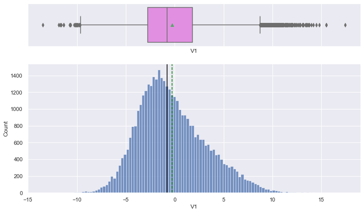

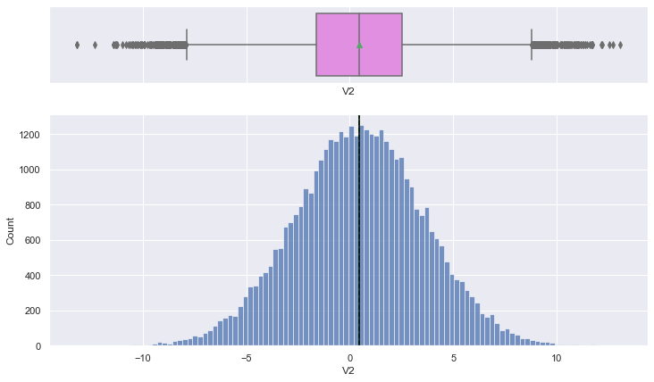

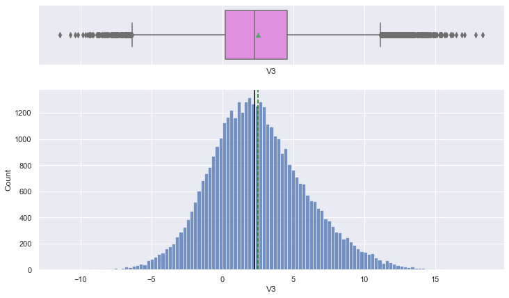

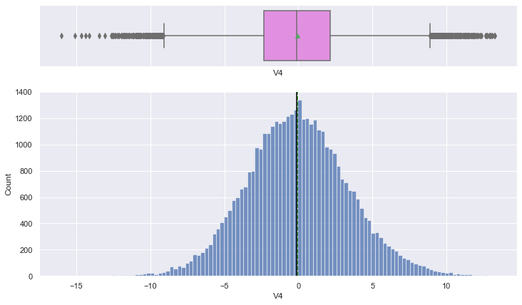

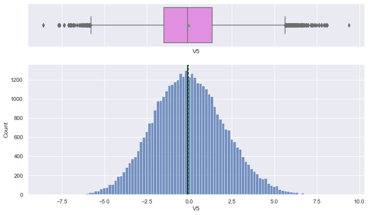

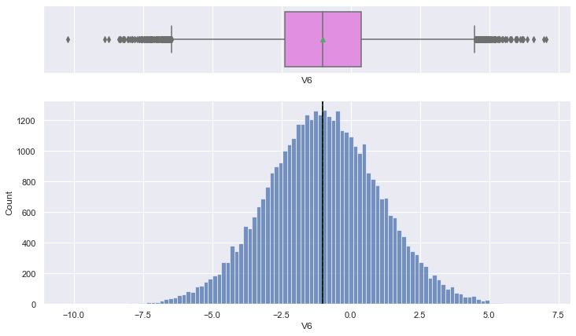

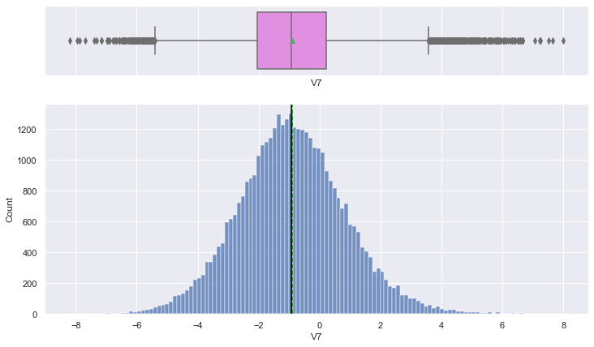

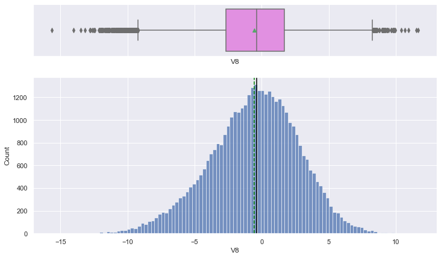

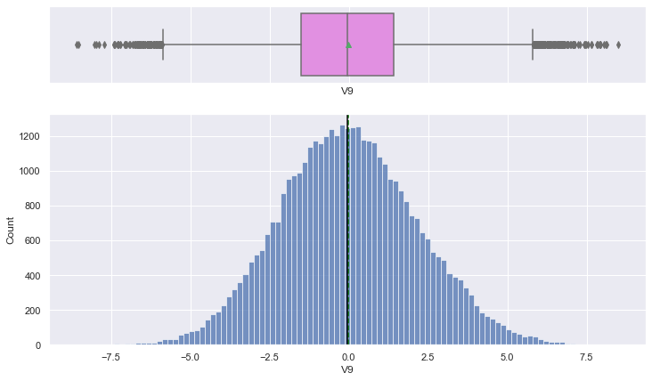

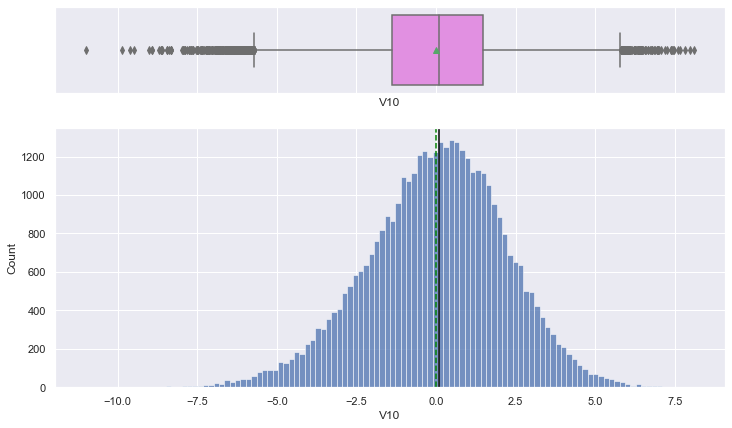

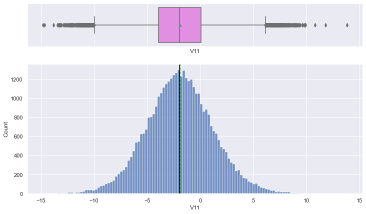

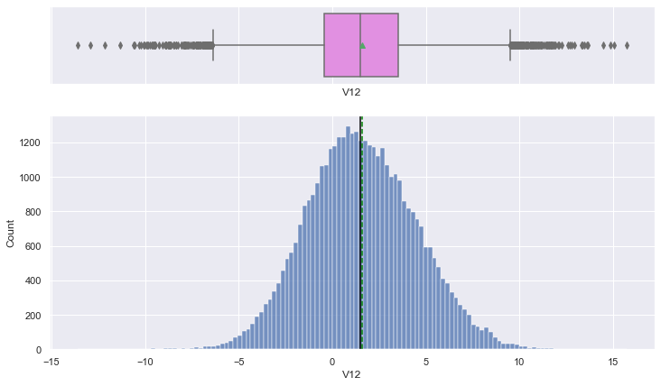

[29 more figures not shown]

```python
# Looping through all 40 variables at once.
for feature in train_df.columns:
    histogram_boxplot(train_df, feature)
```

#### Observations

1. The distribution for all the variables is bell-shaped(normal distribution).
2. For all the Variables V1 to V39, the boxplot shows outliers on both the end.
3. Since, we dont know what these columns names are. We will not treat these outliers as they me represent the real market trend.

## Data Pre-processing

#### Data Split

```python
df = train_df.copy()
```

```python
X = df.drop(["Target"], axis=1)
y = df["Target"]
```

```python
X_test = test_data.drop(["Target"],axis = 1)
y_test = test_data["Target"]
```

```python
# Since, the data has already been divided into training and test data. Now, Divinding the data into train and validation.
X_train, X_val, y_train, y_val = train_test_split(
    X, y, test_size=0.25, random_state=1, stratify=y
)
print(X_train.shape, X_val.shape, X_test.shape)
```

```
(30000, 40) (10000, 40) (10000, 40)
```

```python
#### Missing Value Treatment
#We use median to replace the missing values in V1 and V2 columns.
```

```python
imputer = SimpleImputer(strategy="median")
impute = imputer.fit(X_train)

X_train = impute.transform(X_train)
X_val = imputer.transform(X_val)
X_test = imputer.transform(X_test)
```

### Observation

1. There seem to be outliers in every variable. However, without any domain knowledge or actual names of variables, we dont know which values could be of importance and which ones could be noise. Treating them might reduce the real variability in the given data.
2. Hence we donot treat the outliers.
3. Similarly, we donot treat the negative values.
1. We have splitted df(Train.csv) into train and validation so that we can use validation set for performing validations instead of test data.
2. Test data is left untouched as this will be used for testing the final model.
3. Test data is kept away from train data ensuring no data leakage.

## Model evaluation criterion

### 3 types of cost are associated with the provided problem

1. Replacement cost - False Negatives - Predicting no failure, while there will be a failure
2. Inspection cost - False Positives - Predicting failure, while there is no failure
3. Repair cost - True Positives - Predicting failure correctly

### How to reduce the overall cost?

- We need to create a customized metric, that can help to bring down the overall cost.
- The cost associated with any model = TP *15000 + FP* 5000 + FN * 40000
- And the minimum possible cost will be when, the model will be able to identify all failures, in that case, the cost will be (TP + FN) * 15000
- So, we will try to maximize `Minimum cost/Cost associated with model`

**Let's create two functions to calculate different metrics and confusion matrix, so that we don't have to use the same code repeatedly for each model.**

```python
# defining a function to compute different metrics to check performance of a classification model built using sklearn
def model_performance_classification_sklearn(model, predictors, target):
    """
    Function to compute different metrics to check classification model performance

    model: classifier
    predictors: independent variables
    target: dependent variable
    """

    TP = confusion_matrix(target, model.predict(predictors))[1, 1]
    FP = confusion_matrix(target, model.predict(predictors))[0, 1]
    FN = confusion_matrix(target, model.predict(predictors))[1, 0]
    Cost = TP * 15 + FP * 5 + FN * 40  # maintenance cost by using model
    Min_Cost = (TP + FN) * 15  # minimum possible maintenance cost = number of actual positives
    Percent = Min_Cost / Cost  # ratio of minimum possible maintenance cost and maintenance cost by model

    # predicting using the independent variables
    pred = model.predict(predictors)

    acc = accuracy_score(target, pred)  # to compute Accuracy
    recall = recall_score(target, pred)  # to compute Recall
    precision = precision_score(target, pred)  # to compute Precision
    f1 = f1_score(target, pred)  # to compute F1-score

    # creating a dataframe of metrics
    df_perf = pd.DataFrame(
        {
            "Accuracy": acc,
            "Recall": recall,
            "Precision": precision,
            "F1": f1,
            "Minimum_Vs_Model_cost": Percent,
        },
        index=[0],
    )

    return df_perf
```

```python
def confusion_matrix_sklearn(model, predictors, target):
    """
    To plot the confusion_matrix with percentages

    model: classifier
    predictors: independent variables
    target: dependent variable
    """
    y_pred = model.predict(predictors)
    cm = confusion_matrix(target, y_pred)
    labels = np.asarray(
        [
            ["{0:0.0f}".format(item) + "\n{0:.2%}".format(item / cm.flatten().sum())]
            for item in cm.flatten()
        ]
    ).reshape(2, 2)

    plt.figure(figsize=(6, 4))
    sns.heatmap(cm, annot=labels, fmt="")
    plt.ylabel("True label")
    plt.xlabel("Predicted label")
```

## **Defining scorer to be used for hyperparameter tuning**

- Every prediction of a classification model will be either a TP, FP, FN or TN.
- Till now at most of the places we wanted to reduce False negatives and hence we tried to maximize "Recall".
- To maximize Recall, we used Recall as a **scorer** in hyperparameter tuning.
- Here, we not only want to minimize false negatives but also false positives and we are also given the costs associated with each type of prediction.
- So, overall we want to reduce the maintenance cost which is: `TP*(Repair cost) + FN*(Replacement cost) + FP*(Inspection cost)`
- In simple language, we can say that we are assigning different weightage to the different types of predictions.
- Do we have any such metric which can help us minimize the maintenance cost? i.e., help us reduce FP and FN as per the weightage - We don't have any such inbuilt metric.
- In sklearn, we can define **custom scorers** also as per our need.
- For this classification problem, we need to reduce the maintenance cost, which can be reiterated as:
  - Minimize (maintenance cost)
  - Maximize (1/maintenance cost)
  - Maximize (minimum possible maintenance cost/maintenance cost)
- Eventually, all 3 metrics will do the same work in the backend and the only difference will be in the scale of the values of the metric.
- The metric provided in the next cell is to `maximize(minimum possible maintenance cost/maintenance cost)`
- You can modify the metric as per convenience and use it further to tune the models.

```python
# defining metric to be used for optimization and with cross-validation
def Minimum_Vs_Model_cost(y_train, y_pred):
    """
    We want the model to optimize the maintenance cost and reduce it to the lowest possible value.
    The lowest possible maintenance cost will be achieved when each sample is predicted correctly.

    In such a scenario, the maintenance cost will be the total number of failures times the maintenance cost of replacing one generator,
    which is given by (TP + FN) * 40 (i.e., the actual positives*40).
    For any other scenario,
    the maintenance cost associated with the model will be given by (TP * 15 + FP * 5 + FN * 40).

    We will use the ratio of these two maintenance costs as the cost function for our model.
    The greater the ratio, the lower the associated maintenance cost and the better the model.
    """
    TP = confusion_matrix(y_train, y_pred)[1, 1]
    FP = confusion_matrix(y_train, y_pred)[0, 1]
    FN = confusion_matrix(y_train, y_pred)[1, 0]
    return ((TP + FN) * 15) / (TP * 15 + FP * 5 + FN * 40)


# A value of .80 here, will represent that the minimum maintenance cost is 80% of the maintenance cost associated with the model.
# Since minimum maintenance cost is constant for any data, when minimum cost will become 100% of maintenance cost associated with the model
# Model will have give the least possible maintenance cost.


# Type of scoring used to compare parameter combinations
scorer = metrics.make_scorer(Minimum_Vs_Model_cost, greater_is_better=True)

# Higher the values, the lower the maintenance cost
```

## Model Building with Original data

```python
models = []  # Empty list to store all the models

# Appending models into the list
models.append(("Bagging", BaggingClassifier(random_state=1)))
models.append(("Random forest", RandomForestClassifier(random_state=1)))
models.append(("GBM", GradientBoostingClassifier(random_state=1)))
models.append(("Adaboost", AdaBoostClassifier(random_state=1)))
models.append(("LogisticRegression", LogisticRegression(random_state=1)))
models.append(("dtree", DecisionTreeClassifier(random_state=1)))

results = []  # Empty list to store all model's CV scores
names = []  # Empty list to store name of the models


# loop through all models to get the mean cross validated score
print("\n" "Cross-Validation Performance:" "\n")

for name, model in models:
    scoring = scorer
    kfold = StratifiedKFold(
        n_splits=5, shuffle=True, random_state=1
    )  # Setting number of splits equal to 5
    cv_result = cross_val_score(
        estimator=model, X=X_train, y=y_train, scoring=scoring, cv=kfold
    )
    results.append(cv_result)
    names.append(name)
    print("{}: {}".format(name, cv_result.mean() * 100))

print("\n" "Training Performance:" "\n")

for name, model in models:
    model.fit(X_train, y_train)
    scores = Minimum_Vs_Model_cost(y_train, model.predict(X_train)) * 100
    print("{}: {}".format(name, scores))

print("\n" "Validation Performance:" "\n")

for name, model in models:
    model.fit(X_train, y_train)
    scores_val = Minimum_Vs_Model_cost(y_val, model.predict(X_val)) * 100
    print("{}: {}".format(name, scores_val))
```

```
Cross-Validation Performance:

Bagging: 68.86574469253958
Random forest: 71.52966747632996
GBM: 67.35879816374911
Adaboost: 59.88430481901255
LogisticRegression: 52.948994378378856
dtree: 65.12035300489133

Training Performance:

Bagging: 91.43281917859134
Random forest: 100.0
GBM: 72.94292068198665
Adaboost: 61.3160518444666
LogisticRegression: 53.03438611620136
dtree: 100.0

Validation Performance:

Bagging: 68.89168765743074
Random forest: 71.81619256017505
GBM: 67.25409836065573
Adaboost: 59.542815674891145
LogisticRegression: 51.99619771863118
dtree: 66.06280193236715
```

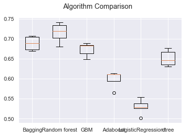

```python
# Plotting boxplots for CV scores of all models defined above
fig = plt.figure()

fig.suptitle("Algorithm Comparison")
ax = fig.add_subplot(111)

plt.boxplot(results)
ax.set_xticklabels(names)

plt.show()
```

### Observation

1. We can see that the Random Forest is giving the highest cross-validated scorer followed by Bagging and GBM.
2. The boxplot shows that the performance of these models are consistent and their performance on the validation set is also good.
3. AdaBoost and Logistic Regression have one outlier each.

## Model Building with Oversampled data

```python
print("Before UpSampling, counts of label 'Yes': {}".format(sum(y_train == 1)))
print("Before UpSampling, counts of label 'No': {} \n".format(sum(y_train == 0)))
```

```
Before UpSampling, counts of label 'Yes': 1640
Before UpSampling, counts of label 'No': 28360
```

```python
# Synthetic Minority Over Sampling Technique
sm = SMOTE(sampling_strategy=1, k_neighbors=5, random_state=1)
X_train_over, y_train_over = sm.fit_resample(X_train, y_train)
```

```python
print("After UpSampling, counts of label 'Yes': {}".format(sum(y_train_over == 1)))
print("After UpSampling, counts of label 'No': {} \n".format(sum(y_train_over == 0)))


print("After UpSampling, the shape of train_X: {}".format(X_train_over.shape))
print("After UpSampling, the shape of train_y: {} \n".format(y_train_over.shape))
```

```
After UpSampling, counts of label 'Yes': 28360
After UpSampling, counts of label 'No': 28360

After UpSampling, the shape of train_X: (56720, 40)
After UpSampling, the shape of train_y: (56720,)
```

```python
models_over = []  # Empty list to store all the models

# Appending models into the list
models_over.append(("Bagging_over", BaggingClassifier(random_state=1)))
models_over.append(("Random forest_over", RandomForestClassifier(random_state=1)))
models_over.append(("GBM_over", GradientBoostingClassifier(random_state=1)))
models_over.append(("Adaboost_over", AdaBoostClassifier(random_state=1)))
models_over.append(("LogisticRegression", LogisticRegression(random_state=1)))
models_over.append(("dtree_over", DecisionTreeClassifier(random_state=1)))

results = []  # Empty list to store all model's CV scores
names = []  # Empty list to store name of the models


# loop through all models to get the mean cross validated score
print("\n" "Cross-Validation Performance:" "\n")

for name, model in models_over:
    scoring = scorer
    kfold = StratifiedKFold(
        n_splits=5, shuffle=True, random_state=1
    )  # Setting number of splits equal to 5
    cv_result = cross_val_score(
        estimator=model, X=X_train_over, y=y_train_over, scoring=scoring, cv=kfold
    )
    results.append(cv_result)
    names.append(name)
    print("{}: {}".format(name, cv_result.mean() * 100))

print("\n" "Training Performance:" "\n")

for name, model in models_over:
    model.fit(X_train_over, y_train_over)
    scores = Minimum_Vs_Model_cost(y_train_over, model.predict(X_train_over)) * 100
    print("{}: {}".format(name, scores))

print("\n" "Validation Performance:" "\n")

for name, model in models_over:
    model.fit(X_train_over, y_train_over)
    scores_val = Minimum_Vs_Model_cost(y_val, model.predict(X_val)) * 100
    print("{}: {}".format(name, scores_val))
```

```
Cross-Validation Performance:

Bagging_over: 95.40942899036293
Random forest_over: 96.92752086101537
GBM_over: 86.76274431000867
Adaboost_over: 82.87444544309412
LogisticRegression: 80.0088377103361
dtree_over: 94.13857336531703

Training Performance:

Bagging_over: 99.69884106542297
Random forest_over: 100.0
GBM_over: 86.83582028618669
Adaboost_over: 82.97897241836695
LogisticRegression: 80.02182071274724
dtree_over: 100.0

Validation Performance:

Bagging_over: 75.90194264569843
Random forest_over: 81.23762376237624
GBM_over: 73.1935771632471
Adaboost_over: 56.295025728987994
LogisticRegression: 50.26033690658499
dtree_over: 64.65721040189125
```

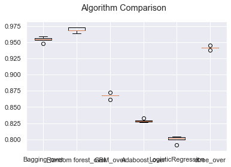

```python
# Plotting boxplots for CV scores of all models defined above
fig = plt.figure()

fig.suptitle("Algorithm Comparison")
ax = fig.add_subplot(111)

plt.boxplot(results)
ax.set_xticklabels(names)

plt.show()
```

## Model Building with Undersampled data

```python
print("Before UpSampling, counts of label 'Yes': {}".format(sum(y_train == 1)))
print("Before UpSampling, counts of label 'No': {} \n".format(sum(y_train == 0)))
```

```
Before UpSampling, counts of label 'Yes': 1640
Before UpSampling, counts of label 'No': 28360
```

```python
# Random undersampler for under sampling the data
rus = RandomUnderSampler(random_state=1, sampling_strategy=1)
X_train_un, y_train_un = rus.fit_resample(X_train, y_train)
```

```python
print("After Under Sampling, counts of label 'Yes': {}".format(sum(y_train_un == 1)))
print("After Under Sampling, counts of label 'No': {} \n".format(sum(y_train_un == 0)))


print("After Under Sampling, the shape of train_X: {}".format(X_train_un.shape))
print("After UpSampling, the shape of train_y: {} \n".format(y_train_un.shape))
```

```
After Under Sampling, counts of label 'Yes': 1640
After Under Sampling, counts of label 'No': 1640

After Under Sampling, the shape of train_X: (3280, 40)
After UpSampling, the shape of train_y: (3280,)
```

```python
models_un = []  # Empty list to store all the models

# Appending models into the list
models_un.append(("Bagging_un", BaggingClassifier(random_state=1)))
models_un.append(("Random forest_un", RandomForestClassifier(random_state=1)))
models_un.append(("GBM_un", GradientBoostingClassifier(random_state=1)))
models_un.append(("Adaboost_un", AdaBoostClassifier(random_state=1)))
models_un.append(("LogisticRegression", LogisticRegression(random_state=1)))
models_un.append(("dtree_un", DecisionTreeClassifier(random_state=1)))

results = []  # Empty list to store all model's CV scores
names = []  # Empty list to store name of the models


# loop through all models to get the mean cross validated score
print("\n" "Cross-Validation Performance:" "\n")

for name, model in models_un:
    scoring = scorer
    kfold = StratifiedKFold(
        n_splits=5, shuffle=True, random_state=1
    )  # Setting number of splits equal to 5
    cv_result = cross_val_score(
        estimator=model, X=X_train_un, y=y_train_un, scoring=scoring, cv=kfold
    )
    results.append(cv_result)
    names.append(name)
    print("{}: {}".format(name, cv_result.mean() * 100))

print("\n" "Training Performance:" "\n")

for name, model in models_un:
    model.fit(X_train_un, y_train_un)
    scores = Minimum_Vs_Model_cost(y_train_un, model.predict(X_train_un)) * 100
    print("{}: {}".format(name, scores))

print("\n" "Validation Performance:" "\n")
for name, model in models_un:
    model.fit(X_train_un, y_train_un)
    scores_val = Minimum_Vs_Model_cost(y_val, model.predict(X_val)) * 100
    print("{}: {}".format(name, scores_val))
```

```
Cross-Validation Performance:

Bagging_un: 81.69551921903387
Random forest_un: 84.67413072888996
GBM_un: 82.88956467253165
Adaboost_un: 80.05315674951575
LogisticRegression: 77.65522788135344
dtree_un: 77.45754336793459

Training Performance:

Bagging_un: 96.69811320754717
Random forest_un: 100.0
GBM_un: 87.65366114377339
Adaboost_un: 83.05199189736663
LogisticRegression: 77.73739927318691
dtree_un: 100.0

Validation Performance:

Bagging_un: 67.36453201970444
Random forest_un: 73.62045760430686
GBM_un: 69.18212478920742
Adaboost_un: 52.26114649681529
LogisticRegression: 49.19064748201439
dtree_un: 49.757428744693755
```

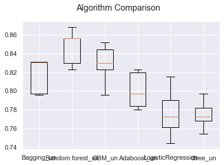

```python
# Plotting boxplots for CV scores of all models defined above
fig = plt.figure()

fig.suptitle("Algorithm Comparison")
ax = fig.add_subplot(111)

plt.boxplot(results)
ax.set_xticklabels(names)

plt.show()
```

### Observation

1. We can see that the Random Forest_under is giving the highest cross-validated scorer followed by GBM_under and Bagging_under.
2. The boxplot shows that the performance of the above three models are consistent and their performance on the validation set is also good.

## Model Selection

1. Random Forest_over (Random Forest - OverSampling)
2. GBM_over (GBM OverSampling)
3. Random Forest_under (Random Forest UnderSampling)

##### These models have high score value. Since, our aim is to increase the scorer value.

Score value = Minimum cost/Cost associated with model

## HyperparameterTuning

- **Hyperparameter tuning can take a long time to run, so to avoid that time complexity - you can use the following grids, wherever required.**

#### For XGBoost:

param_grid={'n_estimators':np.arange(150,300,50),'scale_pos_weight':[5,10], 'learning_rate':[0.1,0.2], 'gamma':[0,3,5], 'subsample':[0.8,0.9]}

#### For Gradient Boosting:

param_grid = { "init": [AdaBoostClassifier(random_state=1),DecisionTreeClassifier(random_state=1)], "n_estimators": np.arange(75,150,25), "learning_rate": [0.2, 0.05, 1], "subsample":[0.5,0.7], "max_features":[0.5,0.7]}

#### For Adaboost:

param_grid = { "n_estimators": np.arange(10, 110, 20), "learning_rate": [ 0.2, 0.05, 1], "base_estimator": [ DecisionTreeClassifier(max_depth=1, random_state=1), DecisionTreeClassifier(max_depth=2, random_state=1), DecisionTreeClassifier(max_depth=3, random_state=1)]}

#### For logistic Regression:

param_grid = {'C': np.arange(0.1,1.1,0.1)}

#### For Bagging Classifier:

param_grid = { 'max_samples': [0.8,0.9], 'max_features': [0.8,0.9], 'n_estimators' : [40,50]}

#### For Random Forest:

param_grid = { "n_estimators": [150,250], "min_samples_leaf": np.arange(1, 3), "max_features": ['sqrt','log2'], "max_samples": np.arange(0.2, 0.6, 0.1)}

#### For Decision Trees:

param_grid = {'max_depth': np.arange(2,20), 'min_samples_leaf': [1, 2, 5, 7], 'max_leaf_nodes' : [5, 10,15], 'min_impurity_decrease': [0.0001,0.001] }

### Random Forest - OverSampled

#### Using RandomizedSearchCV

```python
# Creating pipeline
model = RandomForestClassifier(random_state=1)

# Parameter grid to pass in RandomizedSearchCV
param_grid = { "n_estimators": [150,250], "min_samples_leaf": np.arange(1, 3), "max_features": ['sqrt','log2'], "max_samples": np.arange(0.2, 0.6, 0.1)}

# Type of scoring used to compare parameter combinations
scorer = metrics.make_scorer(Minimum_Vs_Model_cost, greater_is_better=True)

# Calling RandomizedSearchCV
randomized_cv = RandomizedSearchCV(
    estimator=model,
    param_distributions=param_grid,
    n_iter=20,
    scoring=scorer,
    cv=5,
    random_state=1,
)

# Fitting parameters in RandomizedSearchCV
randomized_cv.fit(X_train_over, y_train_over)

print(
    "Best parameters are {} with CV score={}:".format(
        randomized_cv.best_params_, randomized_cv.best_score_
    )
)
```

```
Best parameters are {'n_estimators': 250, 'min_samples_leaf': 1, 'max_samples': 0.5000000000000001, 'max_features': 'sqrt'} with CV score=0.9588968858404104:
```

```python
# Creating new pipeline with best parameters
RandomForest_over_tuned = RandomForestClassifier(
    random_state=1, n_estimators= 250, min_samples_leaf= 1, max_samples=0.5000000000000001, max_features= "sqrt"
)

# Fit the model on training data
RandomForest_over_tuned.fit(X_train_over, y_train_over)
```

```
RandomForestClassifier(max_features='sqrt', max_samples=0.5000000000000001,
                       n_estimators=250, random_state=1)
```

```python
# Calculating different metrics on train set
RandomForest_over_random_train = model_performance_classification_sklearn(
    RandomForest_over_tuned, X_train_over, y_train_over
)
print("Training performance:")
RandomForest_over_random_train
```

```
Training performance:
```

|  | Accuracy | Recall | Precision | F1 | Minimum_Vs_Model_cost |
| --- | --- | --- | --- | --- | --- |
| 0 | 0.998872 | 0.998025 | 0.999717 | 0.998871 | 0.996626 |

```python
# Calculating different metrics on validation set
RF_over_random_val = model_performance_classification_sklearn(RandomForest_over_tuned, X_val, y_val)
print("Validation performance:")
RF_over_random_val
```

```
Validation performance:
```

|  | Accuracy | Recall | Precision | F1 | Minimum_Vs_Model_cost |
| --- | --- | --- | --- | --- | --- |
| 0 | 0.9905 | 0.872029 | 0.950199 | 0.909438 | 0.813988 |

[figure not shown]

```python
# creating confusion matrix
confusion_matrix_sklearn(RandomForest_over_tuned, X_val, y_val)
```

### Observation

1. After tuning the mode, we see better results. The Minimum Vs Model cost value has slightly gone up.
2. Lets see how the other two models perform after tuning.

### Gradient Boosting - OverSampled

#### Using RandomizedSearchCV

```python
# Creating pipeline
model_gdb = GradientBoostingClassifier(random_state=1)

# Parameter grid to pass in RandomizedSearchCV
param_grid = { "init": [AdaBoostClassifier(random_state=1),DecisionTreeClassifier(random_state=1)], "n_estimators": np.arange(75,150,25), "learning_rate": [0.2, 0.05, 1], "subsample":[0.5,0.7], "max_features":[0.5,0.7]}

# Type of scoring used to compare parameter combinations
scorer = metrics.make_scorer(Minimum_Vs_Model_cost, greater_is_better=True)

# Calling RandomizedSearchCV
randomized_cv = RandomizedSearchCV(
    estimator=model_gdb,
    param_distributions=param_grid,
    n_iter=20,
    scoring=scorer,
    cv=5,
    random_state=1,
)

# Fitting parameters in RandomizedSearchCV
randomized_cv.fit(X_train_over, y_train_over)

print(
    "Best parameters are {} with CV score={}:".format(
        randomized_cv.best_params_, randomized_cv.best_score_
    )
)
```

```
Best parameters are {'subsample': 0.7, 'n_estimators': 75, 'max_features': 0.7, 'learning_rate': 0.05, 'init': DecisionTreeClassifier(random_state=1)} with CV score=0.9399114415621824:
```

```python
# Creating new pipeline with best parameters
gdb_over_tuned = GradientBoostingClassifier(
    subsample= 0.7, n_estimators=75, max_features= 0.7, learning_rate= 0.05, init = DecisionTreeClassifier(random_state=1)
)

# Fit the model on training data
gdb_over_tuned.fit(X_train_over, y_train_over)
```

```
GradientBoostingClassifier(init=DecisionTreeClassifier(random_state=1),
                           learning_rate=0.05, max_features=0.7,
                           n_estimators=75, subsample=0.7)
```

```python
# Calculating different metrics on train set
gdb_over_random_train = model_performance_classification_sklearn(
    gdb_over_tuned, X_train_over, y_train_over
)
print("Training performance:")
gdb_over_random_train
```

```
Training performance:
```

|  | Accuracy | Recall | Precision | F1 | Minimum_Vs_Model_cost |
| --- | --- | --- | --- | --- | --- |
| 0 | 1.0 | 1.0 | 1.0 | 1.0 | 1.0 |

```python
# Calculating different metrics on validation set
gdb_over_random_val = model_performance_classification_sklearn(gdb_over_tuned, X_val, y_val)
print("Validation performance:")
gdb_over_random_val
```

```
Validation performance:
```

|  | Accuracy | Recall | Precision | F1 | Minimum_Vs_Model_cost |
| --- | --- | --- | --- | --- | --- |
| 0 | 0.9511 | 0.813528 | 0.534856 | 0.645395 | 0.646572 |

[figure not shown]

```python
# creating confusion matrix
confusion_matrix_sklearn(RandomForest_over_tuned, X_val, y_val)
```

### Observation

1. This model took very long time to run.
2. The values are low in validation compared to training set. The model are overfitting.

### RandomForest - UnderSampled

#### Using RandomSearchCV

```python
# Creating pipeline
model_rf_under = RandomForestClassifier(random_state=1)

# Parameter grid to pass in RandomizedSearchCV
param_grid = { "n_estimators": [150,250], "min_samples_leaf": np.arange(1, 3), "max_features": ['sqrt','log2'], "max_samples": np.arange(0.2, 0.6, 0.1)}

# Type of scoring used to compare parameter combinations
scorer = metrics.make_scorer(Minimum_Vs_Model_cost, greater_is_better=True)

# Calling RandomizedSearchCV
randomized_cv = RandomizedSearchCV(
    estimator=model_rf_under,
    param_distributions=param_grid,
    n_iter=20,
    scoring=scorer,
    cv=5,
    random_state=1,
)

# Fitting parameters in RandomizedSearchCV
randomized_cv.fit(X_train_un, y_train_un)

print(
    "Best parameters are {} with CV score={}:".format(
        randomized_cv.best_params_, randomized_cv.best_score_
    )
)
```

```
Best parameters are {'n_estimators': 150, 'min_samples_leaf': 2, 'max_samples': 0.4000000000000001, 'max_features': 'sqrt'} with CV score=0.8449307827560755:
```

```python
# Creating new pipeline with best parameters
RandomForest_un_tuned = RandomForestClassifier(
    random_state=1, n_estimators= 150, min_samples_leaf= 2, max_samples=0.4000000000000001, max_features= "sqrt"
)

# Fit the model on training data
RandomForest_un_tuned.fit(X_train_un, y_train_un)
```

```
RandomForestClassifier(max_features='sqrt', max_samples=0.4000000000000001,
                       min_samples_leaf=2, n_estimators=150, random_state=1)
```

```python
# Calculating different metrics on train set
RandomForest_un_random_train = model_performance_classification_sklearn(
    RandomForest_un_tuned, X_train_un, y_train_un
)
print("Training performance:")
RandomForest_un_random_train
```

```
Training performance:
```

|  | Accuracy | Recall | Precision | F1 | Minimum_Vs_Model_cost |
| --- | --- | --- | --- | --- | --- |
| 0 | 0.954878 | 0.920732 | 0.98822 | 0.953283 | 0.880458 |

```python
# Calculating different metrics on validation set
RF_un_random_val = model_performance_classification_sklearn(RandomForest_un_tuned, X_val, y_val)
print("Validation performance:")
RF_un_random_val
```

```
Validation performance:
```

|  | Accuracy | Recall | Precision | F1 | Minimum_Vs_Model_cost |
| --- | --- | --- | --- | --- | --- |
| 0 | 0.9596 | 0.888483 | 0.586248 | 0.706395 | 0.716907 |

[figure not shown]

```python
# creating confusion matrix
confusion_matrix_sklearn(RandomForest_over_tuned, X_val, y_val)
```

### Observation

1. Minimun_Vs_Model_cost value has slightly gone down with hypertuning.

## Model Performance comparison and choosing the final model

### Comparing Model Performances

```python
# training performance comparison

models_train_comp_df = pd.concat(
    [
        RandomForest_over_random_train.T,
        gdb_over_random_train.T,
        RandomForest_un_random_train.T,
    ],
    axis=1,
)
models_train_comp_df.columns = [
    "Random Forest - OverSampled with Randomized search",
    "Gradient Boost - OverSampled with Random search",
    "Random Forest - UnderSampled with Randomized search",
]
print("Training performance comparison:")
models_train_comp_df
```

```
Training performance comparison:
```

|  | Random Forest - OverSampled with Randomized search | Gradient Boost - OverSampled with Random search | Random Forest - UnderSampled with Randomized search |
| --- | --- | --- | --- |
| Accuracy | 0.998872 | 1.0 | 0.954878 |
| Recall | 0.998025 | 1.0 | 0.920732 |
| Precision | 0.999717 | 1.0 | 0.988220 |
| F1 | 0.998871 | 1.0 | 0.953283 |
| Minimum_Vs_Model_cost | 0.996626 | 1.0 | 0.880458 |

```python
# Validation performance comparison

models_val_comp_df = pd.concat(
    [
        RF_over_random_val.T,
        gdb_over_random_val.T,
        RF_un_random_val.T,
    ],
    axis=1,
)
models_val_comp_df.columns = [
    "Random Forest - OverSampled with Randomized search",
    "Gradient Boost - OverSampled with Random search",
    "Random Forest - UnderSampled with Randomized search",
]
print("Validation performance comparison:")
models_val_comp_df
```

```
Validation performance comparison:
```

|  | Random Forest - OverSampled with Randomized search | Gradient Boost - OverSampled with Random search | Random Forest - UnderSampled with Randomized search |
| --- | --- | --- | --- |
| Accuracy | 0.990500 | 0.951100 | 0.959600 |
| Recall | 0.872029 | 0.813528 | 0.888483 |
| Precision | 0.950199 | 0.534856 | 0.586248 |
| F1 | 0.909438 | 0.645395 | 0.706395 |
| Minimum_Vs_Model_cost | 0.813988 | 0.646572 | 0.716907 |

## Test set final performance

#### Performance on the test set

```python
# Calculating different metrics on validation set
RF_over_random_test = model_performance_classification_sklearn(RandomForest_over_tuned, X_test, y_test)
print("Test performance:")
RF_over_random_test
```

```
Test performance:
```

|  | Accuracy | Recall | Precision | F1 | Minimum_Vs_Model_cost |
| --- | --- | --- | --- | --- | --- |
| 0 | 0.9898 | 0.857404 | 0.951318 | 0.901923 | 0.79854 |

### Observation

1. The Minimum_Vs_Model_cost score is 0.81 in validation and 0.79 in test, which shows the performance is generalized.
2. The metric "Minimum_Vs_Model_cost" obtained here is greater than 0.78 on the test data.

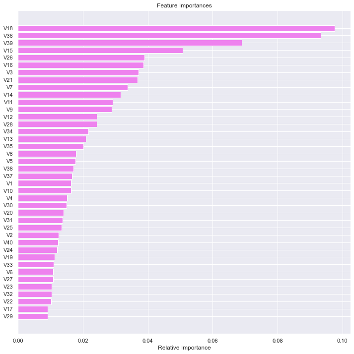

```python
feature_names = X.columns
importances = RandomForest_over_tuned.feature_importances_
indices = np.argsort(importances)

plt.figure(figsize=(12, 12))
plt.title("Feature Importances")
plt.barh(range(len(indices)), importances[indices], color="violet", align="center")
plt.yticks(range(len(indices)), [feature_names[i] for i in indices])
plt.xlabel("Relative Importance")
plt.show()
```

### Observation

1. V18 is the important feature followed by V36 and V39.
2. V18, V36, V39, V15, V26, V16, V3 are the top features that influence component wear and Tear.

## Pipelines to build the final model

1. Lets put the final model into production.

### Column Transformer

```python
# creating a list of numerical variables
numerical_features = [
    "V1","V2","V3","V4","V5", "V6","V7","V8","V9","V10",
    "V11","V12","V13","V14","V15", "V16","V17","V18","V19","V20",
    "V21","V22","V23","V24","V25", "V26","V27","V28","V29","V30",
    "V31","V32","V33","V34","V35", "V36","V37","V38","V39","V40","Target",
]

# creating a transformer for numerical variables, which will apply simple imputer on the numerical variables
numeric_transformer = Pipeline(steps=[("imputer", SimpleImputer(strategy="median"))])



# combining categorical transformer and numerical transformer using a column transformer

preprocessor = ColumnTransformer(
    transformers=[
        ("num", numeric_transformer, numerical_features),
    ],
    remainder="passthrough",
)
```

```python
preprocessor
```

```
ColumnTransformer(remainder='passthrough',
                  transformers=[('num',
                                 Pipeline(steps=[('imputer',
                                                  SimpleImputer(strategy='median'))]),
                                 ['V1', 'V2', 'V3', 'V4', 'V5', 'V6', 'V7',
                                  'V8', 'V9', 'V10', 'V11', 'V12', 'V13', 'V14',
                                  'V15', 'V16', 'V17', 'V18', 'V19', 'V20',
                                  'V21', 'V22', 'V23', 'V24', 'V25', 'V26',
                                  'V27', 'V28', 'V29', 'V30', ...])])
```

```python
df = train_df.copy()
df1 = df.copy()
```

```python
# Separating target variable and other variables
X = df1
y = df1["Target"]
```

```python
smt = SMOTE(random_state=1)
# Creating new pipeline with best parameters
model = Pipeline(
    steps=[
        ("pre", preprocessor),('smt', smt),
        (
            "RF_over_tuned_classifier",

RandomForestClassifier(
    random_state=1, n_estimators= 250, min_samples_leaf= 1, max_samples=0.5000000000000001, max_features= "sqrt",
            ),
        ),
    ]
)
# Fit the model on training data
#X_train, X_test, y_train, y_test = tts(X, y, random_state=1)
model.fit(X, y)
```

```
Pipeline(steps=[('pre',
                 ColumnTransformer(remainder='passthrough',
                                   transformers=[('num',
                                                  Pipeline(steps=[('imputer',
                                                                   SimpleImputer(strategy='median'))]),
                                                  ['V1', 'V2', 'V3', 'V4', 'V5',
                                                   'V6', 'V7', 'V8', 'V9',
                                                   'V10', 'V11', 'V12', 'V13',
                                                   'V14', 'V15', 'V16', 'V17',
                                                   'V18', 'V19', 'V20', 'V21',
                                                   'V22', 'V23', 'V24', 'V25',
                                                   'V26', 'V27', 'V28', 'V29',
                                                   'V30', ...])])),
                ('smt', SMOTE(random_state=1)),
                ('RF_over_tuned_classifier',
                 RandomForestClassifier(max_features='sqrt',
                                        max_samples=0.5000000000000001,
                                        n_estimators=250, random_state=1))])
```

# Business Insights and Conclusions